# Внешний курс. Раздел 1.

Репкина Елизавета Андреевна

1132246753@rudn.ru

Российский университет дружбы народов

# Информация

## Докладчик

- Репкина Елизавета Андреевна
- НКАбд-04-24

# Вводная часть

## Цели и задачи

Прохождение внешнего курса “Основы кибербезопасности”. Получение знаний в сфере кибербезопасности.

# Выполнение лабораторной работы

## 1

HTTPS-протокол прикладного уровня, IP-сетевого, UPD и ТСР-транспортного. (рис. 1)

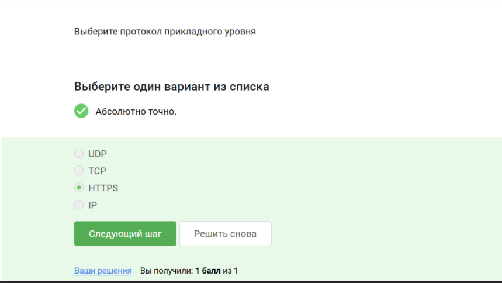

Рисунок 1: Правильный ответ

## 2

ТСР- протокол транспортного уровня (рис. 2)

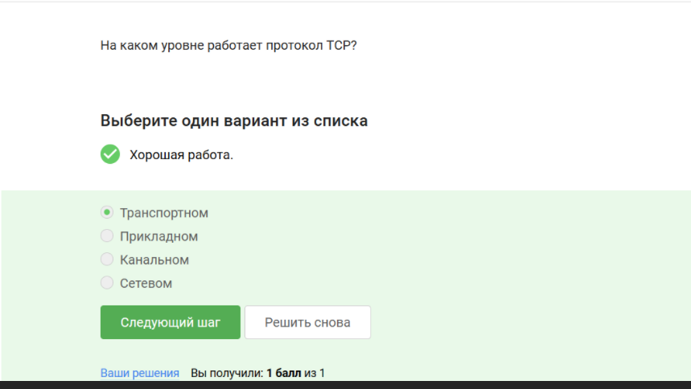

Рисунок 2: Правильный ответ

## 3

Не должно превышать 255 (рис. 3)

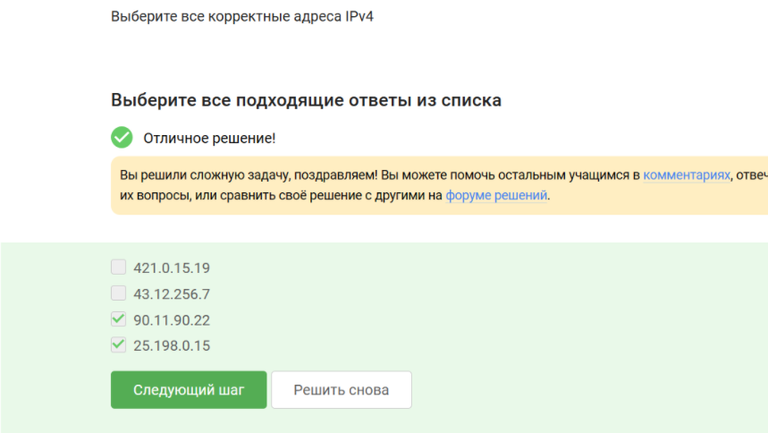

Рисунок 3: Правильный ответ

## 4

DNS используется для преобразования удобно читаемых доменных имен (рис. 4)

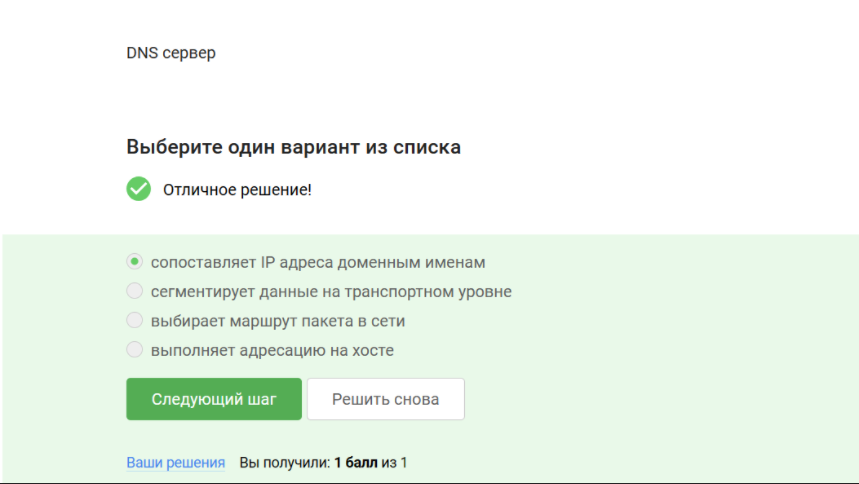

Рисунок 4: Правильный ответ

## 5

Правильная последовательность протоколов указана на (рис. 5)

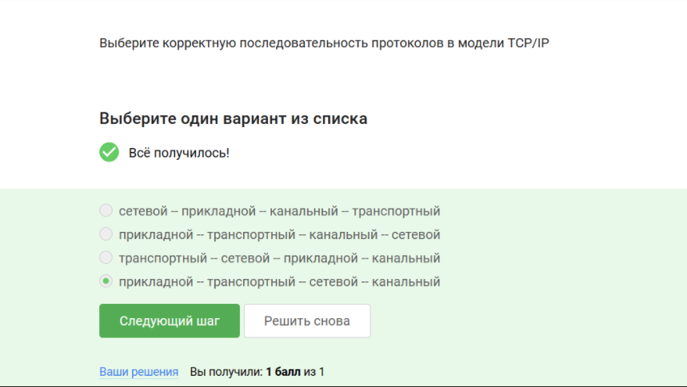

Рисунок 5: Правильный ответ

## 6

HTTP предполагает передачу данных в открытом виде(рис. 6)

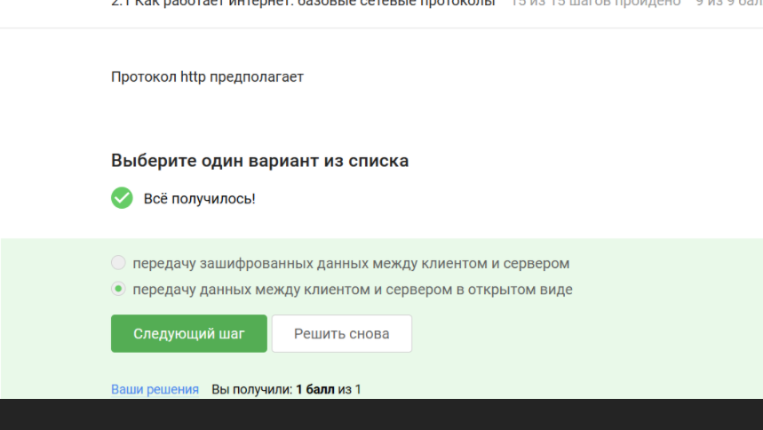

Рисунок 6: Правильный ответ

## 7

HTTPS состоит из рукопожатия и передачи данных (рис. 7)

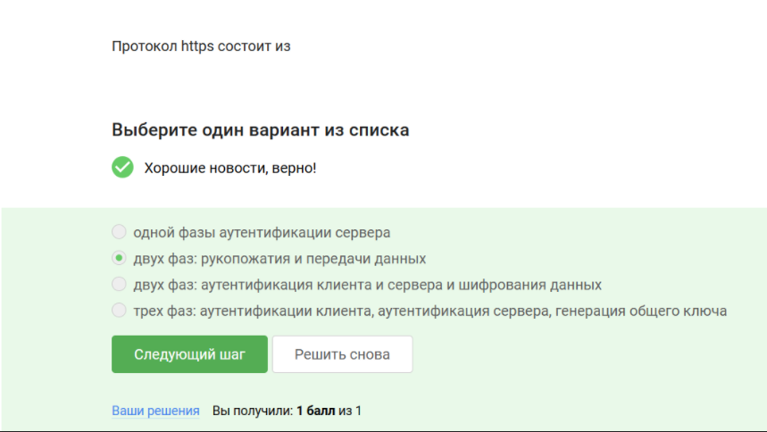

Рисунок 7: Правильный ответ

## 8

Версия протокола выбирается в процессе переговоров (рис. 8)

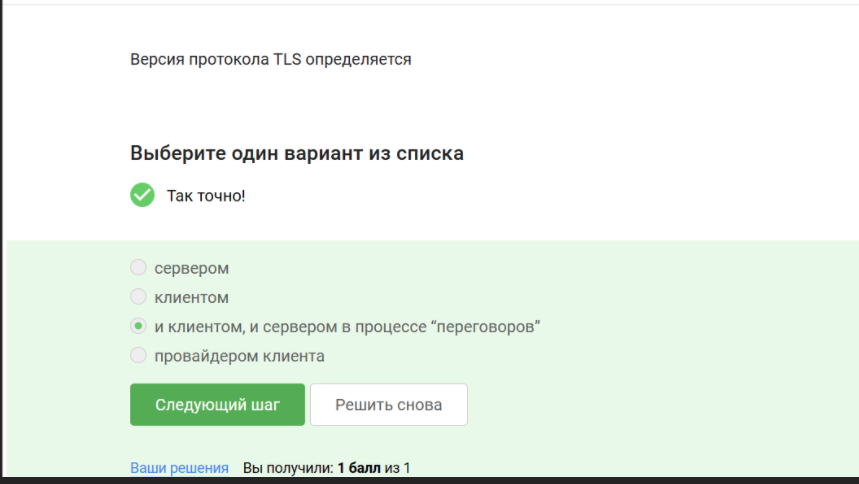

Рисунок 8: Правильный ответ

## 9

Шифрование предусмотрено после фазы рукопожатия (рис. 9)

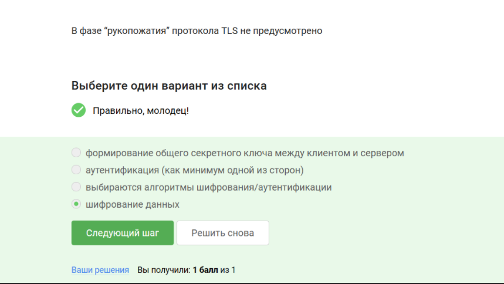

Рисунок 9: Правильный ответ

## 10

Куки не хранят пароли и IP адреса (рис. 10)

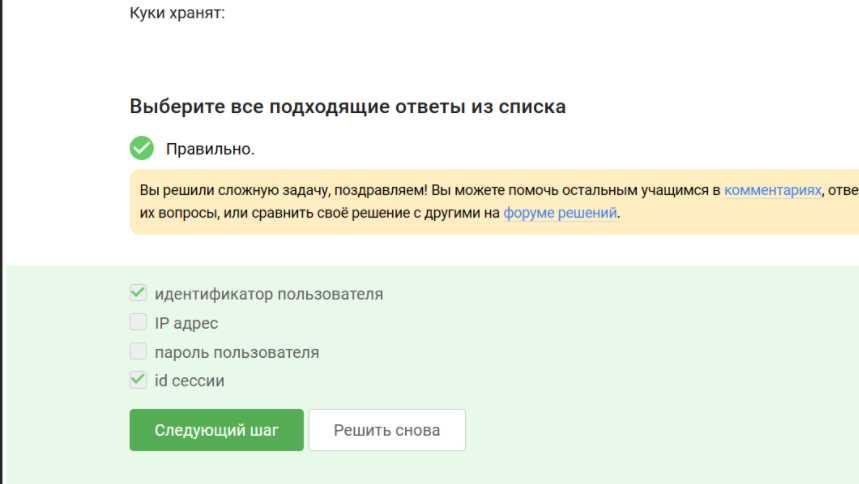

Рисунок 10: Правильный ответ

## 11

Куки не влияет на улучшение надежности соединения (рис. 11)

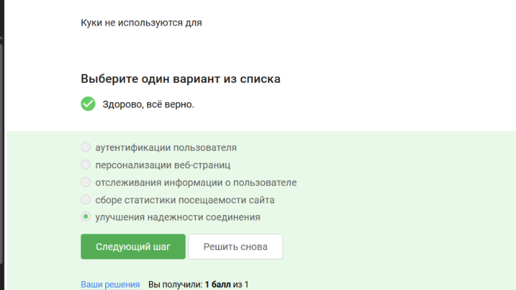

Рисунок 11: Правильный ответ

## 12

Клиент не генерирует куки (рис. 12)

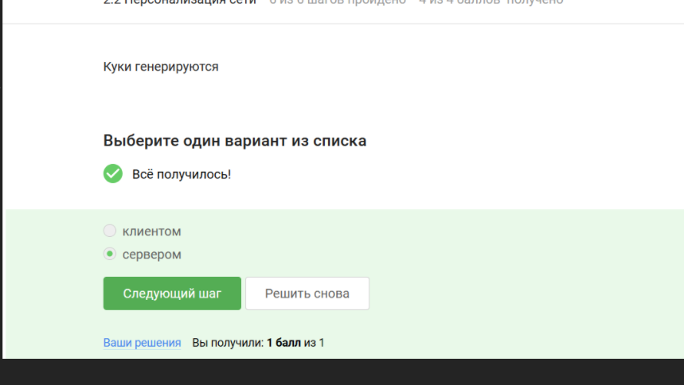

Рисунок 12: Правильный ответ

## 13

Сессионные куки хранятся в браузере только на время пользования веб сайтом (рис. 13)

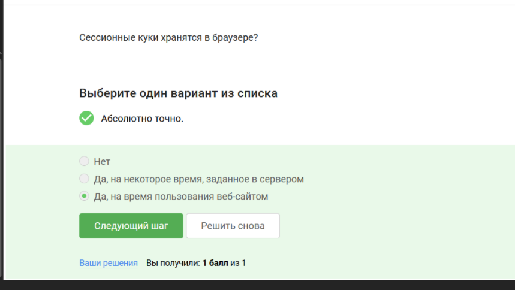

Рисунок 13: Правильный ответ

## 14

TOR-луковая сеть, содержащая 3 промежуточных узла (рис. 14)

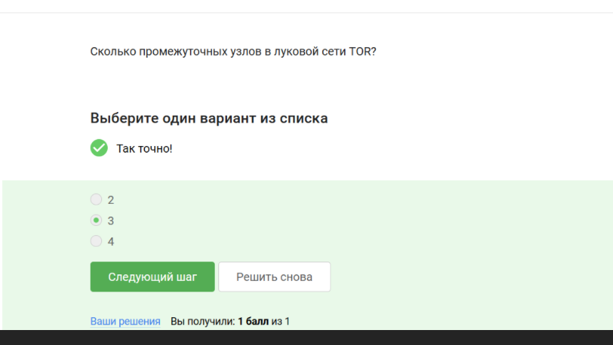

Рисунок 14: Правильный ответ

## 15

В браузере тор не видно промежуточный и охранный узел (рис. 15)

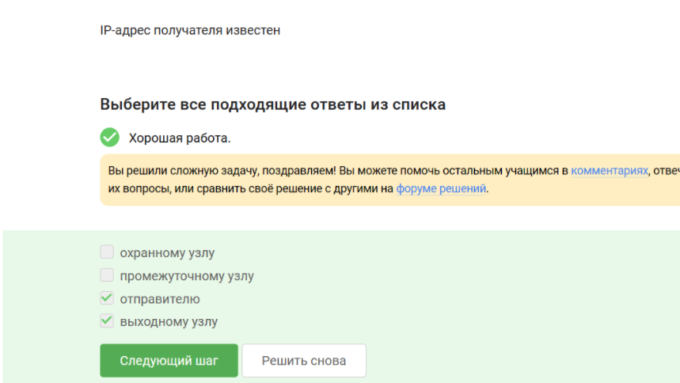

Рисунок 15: Правильный ответ

## 16

Общий секретный ключ генерируется со всеми узлами через которые идет передача (рис. 16)

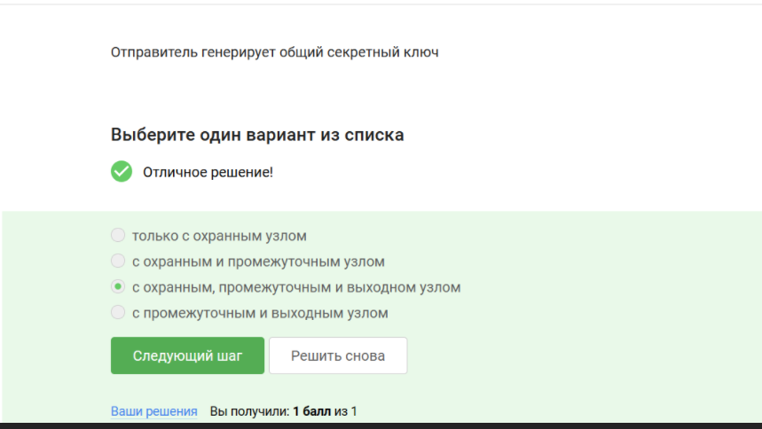

Рисунок 16: Правильный ответ

## 17

Получатель не должен использовать браузер тор для успешного получения пакетов (рис. 17)

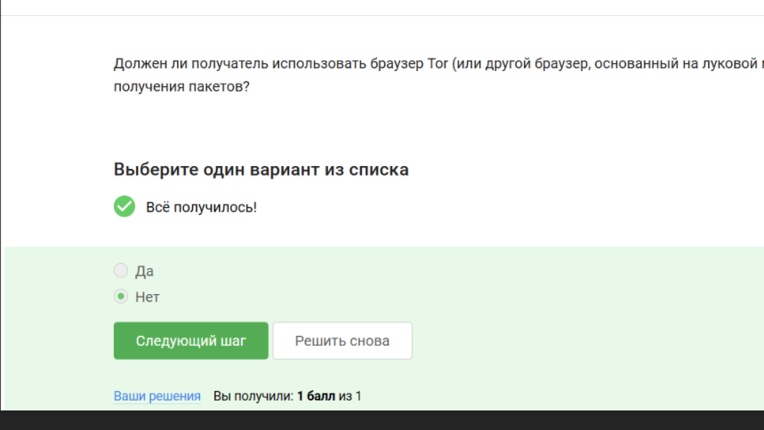

Рисунок 17: Правильный ответ

## 18

Верное опрередение wi-fi (рис. 18)

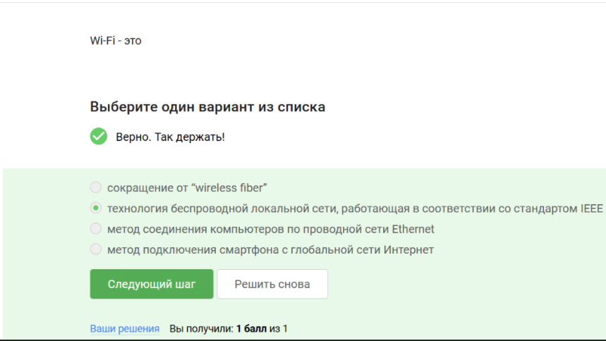

Рисунок 18: Правильный ответ

## 19

Протокол wi-fi работает на канальном уровне (рис. 19)

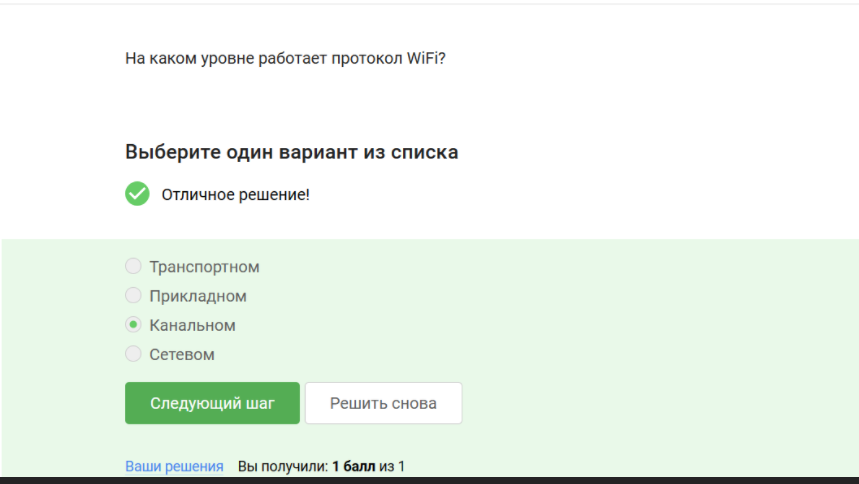

Рисунок 19: Правильный ответ

## 20

WEP не является безопасным методом обеспечения шифрования и аутентификации в сети wi-fi (рис. 20)

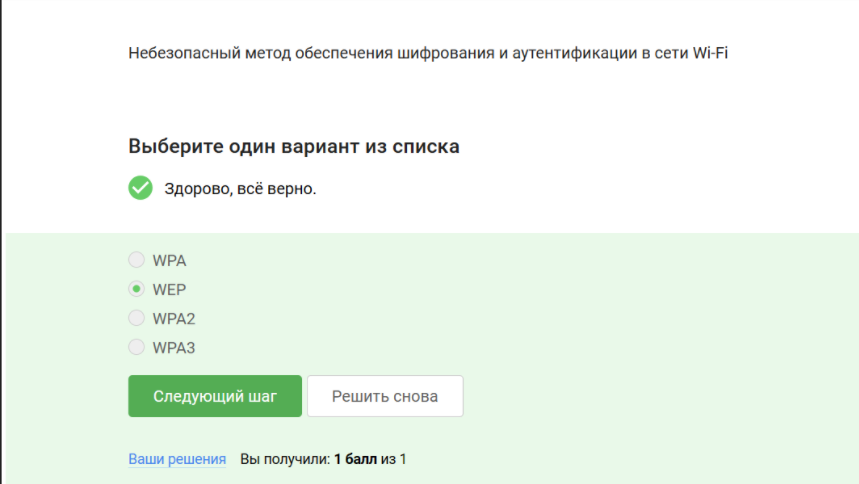

Рисунок 20: Правильный ответ

## 21

После аутентификации устройств данные передаются в зашифрованном виде (рис. 21)

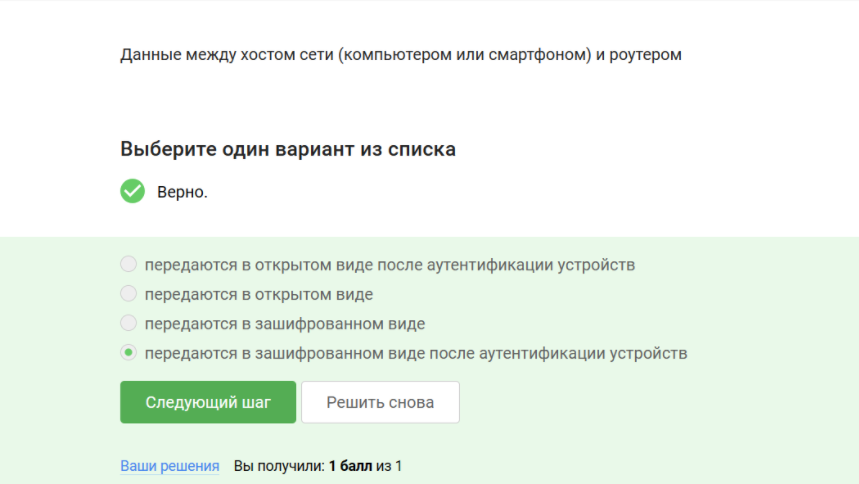

Рисунок 21: Правильный ответ

## 22

WPA2 Personal используется для аутентификации домащней сети (рис. 22)

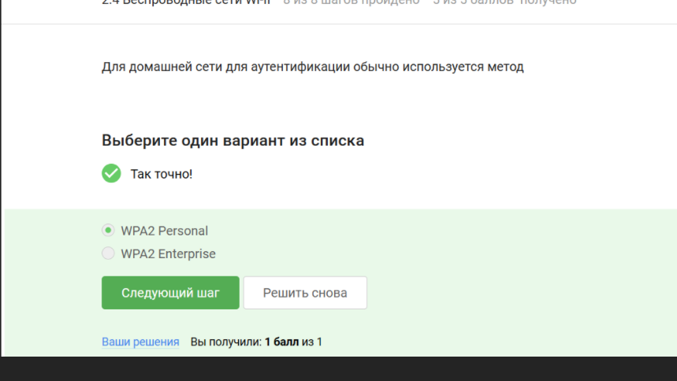

Рисунок 22: Правильный ответ